# Optimal Treatment Analysis

## Outcome Variable

**Outcome Variable:** whz

## Predictor Variables

**Intervention Variable:** exclfeed36

**Adjustment Set:**

- arm
- sex
- W_mage
- meducyrs
- feducyrs
- hhwealth_quart
- hfoodsec
- W_mhtcm
- vagbrth
- W_gagebrth
- W_birthwt
- W_birthlen
- W_nrooms
- W_nchldlt5
- month
- brthmon
- W_parity
- impfloor
- impsan
- safeh20
- delta_W_mage
- delta_meducyrs
- delta_feducyrs
- delta_hhwealth_quart
- delta_hfoodsec
- delta_W_mhtcm
- delta_vagbrth
- delta_W_gagebrth
- delta_W_birthwt
- delta_W_birthlen
- delta_W_nrooms
- delta_W_nchldlt5
- delta_month
- delta_brthmon
- delta_W_parity
- delta_impfloor
- delta_impsan
- delta_safeh20

## Stratifying Variables

The analysis was stratified on these variable(s):

- agecat
- studyid
- country

## Data Summary

| agecat | studyid | country | exclfeed36 | n_cell | n |
| --- | --- | --- | --- | --- | --- |
| Birth | ki0047075b-MAL-ED | BANGLADESH | 1 | 58 | 230 |
| Birth | ki0047075b-MAL-ED | BANGLADESH | 0 | 172 | 230 |
| Birth | ki0047075b-MAL-ED | BRAZIL | 1 | 12 | 177 |
| Birth | ki0047075b-MAL-ED | BRAZIL | 0 | 165 | 177 |
| Birth | ki0047075b-MAL-ED | INDIA | 1 | 5 | 195 |
| Birth | ki0047075b-MAL-ED | INDIA | 0 | 190 | 195 |
| Birth | ki0047075b-MAL-ED | NEPAL | 1 | 11 | 167 |
| Birth | ki0047075b-MAL-ED | NEPAL | 0 | 156 | 167 |
| Birth | ki0047075b-MAL-ED | PERU | 1 | 15 | 266 |
| Birth | ki0047075b-MAL-ED | PERU | 0 | 251 | 266 |
| Birth | ki0047075b-MAL-ED | SOUTH AFRICA | 1 | 0 | 234 |
| Birth | ki0047075b-MAL-ED | SOUTH AFRICA | 0 | 234 | 234 |
| Birth | ki0047075b-MAL-ED | TANZANIA, UNITED REPUBLIC OF | 1 | 1 | 116 |
| Birth | ki0047075b-MAL-ED | TANZANIA, UNITED REPUBLIC OF | 0 | 115 | 116 |
| Birth | ki1000108-CMC-V-BCS-2002 | INDIA | 1 | 3 | 3 |
| Birth | ki1000108-CMC-V-BCS-2002 | INDIA | 0 | 0 | 3 |
| Birth | ki1000108-IRC | INDIA | 1 | 0 | 3 |
| Birth | ki1000108-IRC | INDIA | 0 | 3 | 3 |
| Birth | ki1000109-EE | PAKISTAN | 1 | 0 | 1 |
| Birth | ki1000109-EE | PAKISTAN | 0 | 1 | 1 |
| Birth | ki1101329-Keneba | GAMBIA | 1 | 345 | 1202 |
| Birth | ki1101329-Keneba | GAMBIA | 0 | 857 | 1202 |
| Birth | kiGH5241-JiVitA-3 | BANGLADESH | 1 | 9175 | 11319 |
| Birth | kiGH5241-JiVitA-3 | BANGLADESH | 0 | 2144 | 11319 |
| Birth | kiGH5241-JiVitA-4 | BANGLADESH | 1 | 491 | 602 |
| Birth | kiGH5241-JiVitA-4 | BANGLADESH | 0 | 111 | 602 |
| 6 months | ki0047075b-MAL-ED | BANGLADESH | 1 | 63 | 240 |
| 6 months | ki0047075b-MAL-ED | BANGLADESH | 0 | 177 | 240 |
| 6 months | ki0047075b-MAL-ED | BRAZIL | 1 | 17 | 209 |
| 6 months | ki0047075b-MAL-ED | BRAZIL | 0 | 192 | 209 |

[output cut: 60 more lines]

The following strata were considered:

- agecat: 24 months, studyid: ki0047075b-MAL-ED, country: BANGLADESH
- agecat: 24 months, studyid: ki0047075b-MAL-ED, country: BRAZIL
- agecat: 24 months, studyid: ki0047075b-MAL-ED, country: INDIA
- agecat: 24 months, studyid: ki0047075b-MAL-ED, country: NEPAL
- agecat: 24 months, studyid: ki0047075b-MAL-ED, country: PERU
- agecat: 24 months, studyid: ki0047075b-MAL-ED, country: SOUTH AFRICA
- agecat: 24 months, studyid: ki0047075b-MAL-ED, country: TANZANIA, UNITED REPUBLIC OF
- agecat: 24 months, studyid: ki1000108-CMC-V-BCS-2002, country: INDIA
- agecat: 24 months, studyid: ki1000108-IRC, country: INDIA
- agecat: 24 months, studyid: ki1017093b-PROVIDE, country: BANGLADESH
- agecat: 24 months, studyid: ki1101329-Keneba, country: GAMBIA
- agecat: 24 months, studyid: ki1113344-GMS-Nepal, country: NEPAL
- agecat: 24 months, studyid: ki1148112-LCNI-5, country: MALAWI
- agecat: 24 months, studyid: kiGH5241-JiVitA-3, country: BANGLADESH
- agecat: 24 months, studyid: kiGH5241-JiVitA-4, country: BANGLADESH
- agecat: 6 months, studyid: ki0047075b-MAL-ED, country: BANGLADESH
- agecat: 6 months, studyid: ki0047075b-MAL-ED, country: BRAZIL
- agecat: 6 months, studyid: ki0047075b-MAL-ED, country: INDIA
- agecat: 6 months, studyid: ki0047075b-MAL-ED, country: NEPAL
- agecat: 6 months, studyid: ki0047075b-MAL-ED, country: PERU
- agecat: 6 months, studyid: ki0047075b-MAL-ED, country: SOUTH AFRICA
- agecat: 6 months, studyid: ki0047075b-MAL-ED, country: TANZANIA, UNITED REPUBLIC OF
- agecat: 6 months, studyid: ki1000108-CMC-V-BCS-2002, country: INDIA
- agecat: 6 months, studyid: ki1000108-IRC, country: INDIA
- agecat: 6 months, studyid: ki1000109-EE, country: PAKISTAN
- agecat: 6 months, studyid: ki1000304b-SAS-FoodSuppl, country: INDIA
- agecat: 6 months, studyid: ki1017093b-PROVIDE, country: BANGLADESH
- agecat: 6 months, studyid: ki1101329-Keneba, country: GAMBIA
- agecat: 6 months, studyid: ki1113344-GMS-Nepal, country: NEPAL
- agecat: 6 months, studyid: ki1148112-LCNI-5, country: MALAWI
- agecat: 6 months, studyid: kiGH5241-JiVitA-3, country: BANGLADESH
- agecat: 6 months, studyid: kiGH5241-JiVitA-4, country: BANGLADESH
- agecat: Birth, studyid: ki0047075b-MAL-ED, country: BANGLADESH
- agecat: Birth, studyid: ki0047075b-MAL-ED, country: BRAZIL
- agecat: Birth, studyid: ki0047075b-MAL-ED, country: INDIA
- agecat: Birth, studyid: ki0047075b-MAL-ED, country: NEPAL
- agecat: Birth, studyid: ki0047075b-MAL-ED, country: PERU
- agecat: Birth, studyid: ki0047075b-MAL-ED, country: SOUTH AFRICA
- agecat: Birth, studyid: ki0047075b-MAL-ED, country: TANZANIA, UNITED REPUBLIC OF
- agecat: Birth, studyid: ki1000108-CMC-V-BCS-2002, country: INDIA
- agecat: Birth, studyid: ki1000108-IRC, country: INDIA
- agecat: Birth, studyid: ki1000109-EE, country: PAKISTAN
- agecat: Birth, studyid: ki1101329-Keneba, country: GAMBIA
- agecat: Birth, studyid: kiGH5241-JiVitA-3, country: BANGLADESH
- agecat: Birth, studyid: kiGH5241-JiVitA-4, country: BANGLADESH

### Dropped Strata

- agecat: Birth, studyid: ki0047075b-MAL-ED, country: SOUTH AFRICA
- agecat: Birth, studyid: ki0047075b-MAL-ED, country: TANZANIA, UNITED REPUBLIC OF
- agecat: Birth, studyid: ki1000108-CMC-V-BCS-2002, country: INDIA
- agecat: Birth, studyid: ki1000108-IRC, country: INDIA
- agecat: Birth, studyid: ki1000109-EE, country: PAKISTAN
- agecat: 6 months, studyid: ki0047075b-MAL-ED, country: SOUTH AFRICA
- agecat: 6 months, studyid: ki0047075b-MAL-ED, country: TANZANIA, UNITED REPUBLIC OF
- agecat: 6 months, studyid: ki1000108-CMC-V-BCS-2002, country: INDIA
- agecat: 6 months, studyid: ki1000108-IRC, country: INDIA
- agecat: 6 months, studyid: ki1000304b-SAS-FoodSuppl, country: INDIA
- agecat: 24 months, studyid: ki0047075b-MAL-ED, country: SOUTH AFRICA
- agecat: 24 months, studyid: ki0047075b-MAL-ED, country: TANZANIA, UNITED REPUBLIC OF
- agecat: 24 months, studyid: ki1000108-CMC-V-BCS-2002, country: INDIA
- agecat: 24 months, studyid: ki1000108-IRC, country: INDIA

## Methods Detail

We’re interested in the causal parameters $E[Y_a]$ for all values of $a \in \mathcal{A}$. These parameters represent the mean outcome if, possibly contrary to fact, we intervened to set all units to have $A=a$. Under the randomization and positivity assumptions, these are identified by the statistical parameters $\psi_a=E_W[E_{Y|A,W}(Y|A=a,W)]$. In addition, we’re interested in the mean of $Y$, $E[Y]$ under no intervention (the observed mean). We will estimate these parameters by using SuperLearner to fit the relevant likelihood factors – $E_{Y|A,W}(Y|A=a,W)$ and $p(A=a|W)$, and then updating our likelihood fit using a joint TMLE.

For unadjusted analyses ($W=\{\}$), initial likelihoods were estimated using Lrnr_glm to estimate the simple $E(Y|A)$ and Lrnr_mean to estimate $p(A)$. For adjusted analyses, a small library containing Lrnr_glmnet, Lrnr_xgboost, and Lrnr_mean was used.

Having estimated these parameters, we will then use the delta method to estimate relative risks and attributable risks relative to a prespecified baseline level of $A$.

# Results Detail

## Results Plots

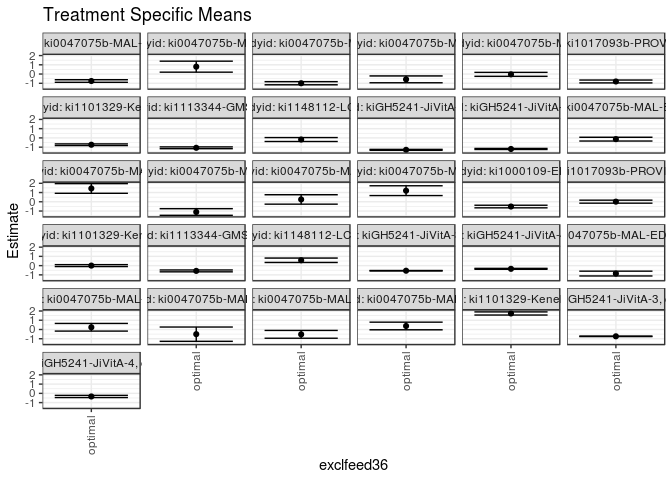

## Results Table

### Parameter: TSM

| agecat | studyid | country | intervention_level | baseline_level | estimate | ci_lower | ci_upper |
| --- | --- | --- | --- | --- | --- | --- | --- |
| Birth | ki0047075b-MAL-ED | BANGLADESH | optimal | observed | -0.8592894 | -1.1191558 | -0.5994229 |
| Birth | ki0047075b-MAL-ED | BRAZIL | optimal | observed | 0.2390772 | -0.1753303 | 0.6534846 |
| Birth | ki0047075b-MAL-ED | INDIA | optimal | observed | -0.5070538 | -1.2805370 | 0.2664294 |
| Birth | ki0047075b-MAL-ED | NEPAL | optimal | observed | -0.5257996 | -0.9475022 | -0.1040971 |
| Birth | ki0047075b-MAL-ED | PERU | optimal | observed | 0.3785914 | -0.0337286 | 0.7909115 |
| Birth | ki1101329-Keneba | GAMBIA | optimal | observed | 1.7334410 | 1.5659498 | 1.9009322 |
| Birth | kiGH5241-JiVitA-3 | BANGLADESH | optimal | observed | -0.7379011 | -0.7627876 | -0.7130146 |
| Birth | kiGH5241-JiVitA-4 | BANGLADESH | optimal | observed | -0.3373939 | -0.4543812 | -0.2204066 |
| 6 months | ki0047075b-MAL-ED | BANGLADESH | optimal | observed | -0.1338415 | -0.3364867 | 0.0688036 |
| 6 months | ki0047075b-MAL-ED | BRAZIL | optimal | observed | 1.4409283 | 0.9164622 | 1.9653945 |
| 6 months | ki0047075b-MAL-ED | INDIA | optimal | observed | -1.1054233 | -1.4639223 | -0.7469243 |
| 6 months | ki0047075b-MAL-ED | NEPAL | optimal | observed | 0.2517512 | -0.2570115 | 0.7605138 |
| 6 months | ki0047075b-MAL-ED | PERU | optimal | observed | 1.2014516 | 0.6710623 | 1.7318409 |
| 6 months | ki1000109-EE | PAKISTAN | optimal | observed | -0.5152646 | -0.6543496 | -0.3761796 |
| 6 months | ki1017093b-PROVIDE | BANGLADESH | optimal | observed | 0.0117302 | -0.1516208 | 0.1750812 |
| 6 months | ki1101329-Keneba | GAMBIA | optimal | observed | 0.0035036 | -0.1030209 | 0.1100281 |
| 6 months | ki1113344-GMS-Nepal | NEPAL | optimal | observed | -0.5694137 | -0.6699022 | -0.4689252 |
| 6 months | ki1148112-LCNI-5 | MALAWI | optimal | observed | 0.5802647 | 0.3417385 | 0.8187909 |
| 6 months | kiGH5241-JiVitA-3 | BANGLADESH | optimal | observed | -0.5504447 | -0.5741859 | -0.5267035 |
| 6 months | kiGH5241-JiVitA-4 | BANGLADESH | optimal | observed | -0.3459997 | -0.3936808 | -0.2983186 |
| 24 months | ki0047075b-MAL-ED | BANGLADESH | optimal | observed | -0.7546863 | -0.8948244 | -0.6145482 |
| 24 months | ki0047075b-MAL-ED | BRAZIL | optimal | observed | 0.7979589 | 0.2015440 | 1.3943738 |
| 24 months | ki0047075b-MAL-ED | INDIA | optimal | observed | -0.9941399 | -1.1637147 | -0.8245652 |
| 24 months | ki0047075b-MAL-ED | NEPAL | optimal | observed | -0.5736045 | -0.9433918 | -0.2038172 |
| 24 months | ki0047075b-MAL-ED | PERU | optimal | observed | -0.0325893 | -0.2468696 | 0.1816909 |
| 24 months | ki1017093b-PROVIDE | BANGLADESH | optimal | observed | -0.8038055 | -0.9579698 | -0.6496412 |
| 24 months | ki1101329-Keneba | GAMBIA | optimal | observed | -0.7381678 | -0.8286890 | -0.6476466 |
| 24 months | ki1113344-GMS-Nepal | NEPAL | optimal | observed | -1.0696965 | -1.1686433 | -0.9707497 |
| 24 months | ki1148112-LCNI-5 | MALAWI | optimal | observed | -0.1743742 | -0.3868991 | 0.0381507 |
| 24 months | kiGH5241-JiVitA-3 | BANGLADESH | optimal | observed | -1.2895130 | -1.3406964 | -1.2383296 |
| 24 months | kiGH5241-JiVitA-4 | BANGLADESH | optimal | observed | -1.1982797 | -1.2551401 | -1.1414193 |

### Parameter: E(Y)

| agecat | studyid | country | intervention_level | baseline_level | estimate | ci_lower | ci_upper |
| --- | --- | --- | --- | --- | --- | --- | --- |
| Birth | ki0047075b-MAL-ED | BANGLADESH | observed | observed | -0.9773043 | -1.1153078 | -0.8393008 |
| Birth | ki0047075b-MAL-ED | BRAZIL | observed | observed | 0.3837288 | 0.2059602 | 0.5614974 |
| Birth | ki0047075b-MAL-ED | INDIA | observed | observed | -1.0816410 | -1.2241126 | -0.9391694 |
| Birth | ki0047075b-MAL-ED | NEPAL | observed | observed | -0.9126946 | -1.0520834 | -0.7733058 |
| Birth | ki0047075b-MAL-ED | PERU | observed | observed | -0.0602256 | -0.1729666 | 0.0525155 |
| Birth | ki1101329-Keneba | GAMBIA | observed | observed | 1.7015141 | 1.6127308 | 1.7902975 |
| Birth | kiGH5241-JiVitA-3 | BANGLADESH | observed | observed | -0.7445605 | -0.7677110 | -0.7214100 |
| Birth | kiGH5241-JiVitA-4 | BANGLADESH | observed | observed | -0.3861794 | -0.4712311 | -0.3011277 |
| 6 months | ki0047075b-MAL-ED | BANGLADESH | observed | observed | -0.1400243 | -0.2696346 | -0.0104140 |
| 6 months | ki0047075b-MAL-ED | BRAZIL | observed | observed | 0.9717225 | 0.8073791 | 1.1360658 |
| 6 months | ki0047075b-MAL-ED | INDIA | observed | observed | -0.7033969 | -0.8285284 | -0.5782654 |
| 6 months | ki0047075b-MAL-ED | NEPAL | observed | observed | 0.1110452 | -0.0202712 | 0.2423616 |
| 6 months | ki0047075b-MAL-ED | PERU | observed | observed | 1.0562362 | 0.9338834 | 1.1785889 |
| 6 months | ki1000109-EE | PAKISTAN | observed | observed | -0.7256065 | -0.8395859 | -0.6116270 |
| 6 months | ki1017093b-PROVIDE | BANGLADESH | observed | observed | -0.2083706 | -0.2927992 | -0.1239419 |
| 6 months | ki1101329-Keneba | GAMBIA | observed | observed | -0.2009677 | -0.2562623 | -0.1456731 |
| 6 months | ki1113344-GMS-Nepal | NEPAL | observed | observed | -0.6007161 | -0.6897580 | -0.5116742 |
| 6 months | ki1148112-LCNI-5 | MALAWI | observed | observed | 0.3927574 | 0.2737700 | 0.5117448 |
| 6 months | kiGH5241-JiVitA-3 | BANGLADESH | observed | observed | -0.5834618 | -0.6054534 | -0.5614701 |
| 6 months | kiGH5241-JiVitA-4 | BANGLADESH | observed | observed | -0.3973178 | -0.4385298 | -0.3561058 |
| 24 months | ki0047075b-MAL-ED | BANGLADESH | observed | observed | -0.8227962 | -0.9454140 | -0.7001785 |
| 24 months | ki0047075b-MAL-ED | BRAZIL | observed | observed | 0.4466272 | 0.2416144 | 0.6516401 |
| 24 months | ki0047075b-MAL-ED | INDIA | observed | observed | -0.9522907 | -1.0676596 | -0.8369219 |
| 24 months | ki0047075b-MAL-ED | NEPAL | observed | observed | -0.3764474 | -0.4898516 | -0.2630431 |
| 24 months | ki0047075b-MAL-ED | PERU | observed | observed | 0.1302000 | 0.0113848 | 0.2490152 |
| 24 months | ki1017093b-PROVIDE | BANGLADESH | observed | observed | -0.8896181 | -0.9727493 | -0.8064868 |
| 24 months | ki1101329-Keneba | GAMBIA | observed | observed | -0.7973955 | -0.8498696 | -0.7449213 |
| 24 months | ki1113344-GMS-Nepal | NEPAL | observed | observed | -1.1186923 | -1.2105469 | -1.0268377 |
| 24 months | ki1148112-LCNI-5 | MALAWI | observed | observed | -0.0771196 | -0.2204715 | 0.0662323 |
| 24 months | kiGH5241-JiVitA-3 | BANGLADESH | observed | observed | -1.3246418 | -1.3519597 | -1.2973238 |
| 24 months | kiGH5241-JiVitA-4 | BANGLADESH | observed | observed | -1.2418558 | -1.2769820 | -1.2067296 |

### Parameter: PAR

| agecat | studyid | country | intervention_level | baseline_level | estimate | ci_lower | ci_upper |
| --- | --- | --- | --- | --- | --- | --- | --- |
| Birth | ki0047075b-MAL-ED | BANGLADESH | optimal | observed | -0.1180150 | -0.3495003 | 0.1134703 |
| Birth | ki0047075b-MAL-ED | BRAZIL | optimal | observed | 0.1446516 | -0.2328833 | 0.5221866 |
| Birth | ki0047075b-MAL-ED | INDIA | optimal | observed | -0.5745872 | -1.3441792 | 0.1950048 |
| Birth | ki0047075b-MAL-ED | NEPAL | optimal | observed | -0.3868950 | -0.8028703 | 0.0290803 |
| Birth | ki0047075b-MAL-ED | PERU | optimal | observed | -0.4388170 | -0.8459783 | -0.0316557 |
| Birth | ki1101329-Keneba | GAMBIA | optimal | observed | -0.0319269 | -0.1684616 | 0.1046078 |
| Birth | kiGH5241-JiVitA-3 | BANGLADESH | optimal | observed | -0.0066594 | -0.0162748 | 0.0029561 |
| Birth | kiGH5241-JiVitA-4 | BANGLADESH | optimal | observed | -0.0487855 | -0.1431284 | 0.0455574 |
| 6 months | ki0047075b-MAL-ED | BANGLADESH | optimal | observed | -0.0061828 | -0.1760084 | 0.1636428 |
| 6 months | ki0047075b-MAL-ED | BRAZIL | optimal | observed | -0.4692058 | -0.9771450 | 0.0387333 |
| 6 months | ki0047075b-MAL-ED | INDIA | optimal | observed | 0.4020264 | 0.0386597 | 0.7653930 |
| 6 months | ki0047075b-MAL-ED | NEPAL | optimal | observed | -0.1407060 | -0.6326424 | 0.3512304 |
| 6 months | ki0047075b-MAL-ED | PERU | optimal | observed | -0.1452155 | -0.6676306 | 0.3771997 |
| 6 months | ki1000109-EE | PAKISTAN | optimal | observed | -0.2103419 | -0.3059588 | -0.1147249 |
| 6 months | ki1017093b-PROVIDE | BANGLADESH | optimal | observed | -0.2201008 | -0.3653509 | -0.0748507 |
| 6 months | ki1101329-Keneba | GAMBIA | optimal | observed | -0.2044713 | -0.2934888 | -0.1154537 |
| 6 months | ki1113344-GMS-Nepal | NEPAL | optimal | observed | -0.0313024 | -0.0739591 | 0.0113542 |
| 6 months | ki1148112-LCNI-5 | MALAWI | optimal | observed | -0.1875074 | -0.3917363 | 0.0167216 |
| 6 months | kiGH5241-JiVitA-3 | BANGLADESH | optimal | observed | -0.0330170 | -0.0435595 | -0.0224746 |
| 6 months | kiGH5241-JiVitA-4 | BANGLADESH | optimal | observed | -0.0513181 | -0.0724439 | -0.0301923 |
| 24 months | ki0047075b-MAL-ED | BANGLADESH | optimal | observed | -0.0681099 | -0.1470850 | 0.0108651 |
| 24 months | ki0047075b-MAL-ED | BRAZIL | optimal | observed | -0.3513317 | -0.9122120 | 0.2095486 |
| 24 months | ki0047075b-MAL-ED | INDIA | optimal | observed | 0.0418492 | -0.0901624 | 0.1738608 |
| 24 months | ki0047075b-MAL-ED | NEPAL | optimal | observed | 0.1971571 | -0.1610213 | 0.5553355 |
| 24 months | ki0047075b-MAL-ED | PERU | optimal | observed | 0.1627893 | -0.0415004 | 0.3670791 |
| 24 months | ki1017093b-PROVIDE | BANGLADESH | optimal | observed | -0.0858126 | -0.2195810 | 0.0479558 |
| 24 months | ki1101329-Keneba | GAMBIA | optimal | observed | -0.0592276 | -0.1336392 | 0.0151839 |
| 24 months | ki1113344-GMS-Nepal | NEPAL | optimal | observed | -0.0489958 | -0.1008027 | 0.0028111 |
| 24 months | ki1148112-LCNI-5 | MALAWI | optimal | observed | 0.0972546 | -0.0382980 | 0.2328072 |
| 24 months | kiGH5241-JiVitA-3 | BANGLADESH | optimal | observed | -0.0351288 | -0.0788511 | 0.0085935 |
| 24 months | kiGH5241-JiVitA-4 | BANGLADESH | optimal | observed | -0.0435761 | -0.0870856 | -0.0000666 |